# project1_RyanWang

## part 6

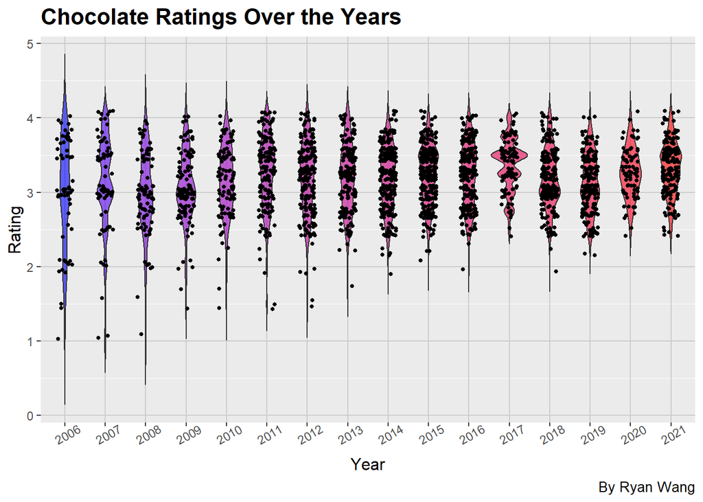

```r
chocolate %>%
    ggplot(aes(
        x = as.factor(review_date),
        y = rating,
        fill = review_date
    )) +
    geom_violin(alpha = 0.6, trim = F) + geom_jitter(width = 0.2, size = 1) +
   scale_fill_gradient(low = "blue", high = "red") +
  labs(x = "Year", y = "Rating", title = "Chocolate Ratings Over the Years",
       caption = "By Ryan Wang")  +
  theme(
    plot.title = element_text(size = 16, face = "bold"),
    axis.title.x = element_text(size = 12),
    axis.text.x = element_text(angle = 30),
    axis.title.y = element_text(size = 12),
    plot.caption = element_text(size = 10),
    legend.position = "none",
    panel.grid.major = element_line(colour = "gray80")
  )
```

- In geom_violin(), I set alpha = 0.6 to add some transparency, and trim = F to not to trim the tails.
- I add geom_jitter() so that the plot will display the original data. I set width = 0.2 to ensure the data points from a certain year do not overlap with the ones from another year. size = 1 to set the size of the points.
- I add the scale_fill_gradient() and customize the color of the violins such that the color changes from blue to red as year goes.
- I add the labs() to customize the labels of y, x axis, title, and the caption.
- Use theme() to customize the size of the title, labels, and caption.
- In theme(), set legend.position = “none” so that the legend will not be displayed.
- In theme(), use axis.text.x = element_text(angle = 30) to rotate the x-axis labels.
- In theme(), use panel.grid.major = element_line(colour = “gray80”) to make the background look differently.